# MY472 Summative

n-2935

AT 2023

# Exercise 1

My public repository can be found [here](https://github.com/n-2935/MY472_Assignment2_Exercise1).

# Exercise 2

This exercise attempts to answer the following question: *“To what extent did different regions of the world implement some form of recommendation or restriction for citizens to stay at home over the course of 2020-2022? How do the introduction of these restrictions compare to the regions’ implementation of income support over the same period?”*

### Covid policies by region (2020-2022)

*The bar chart below reports the level of implementation of different covid-19 policies accross different regions.*

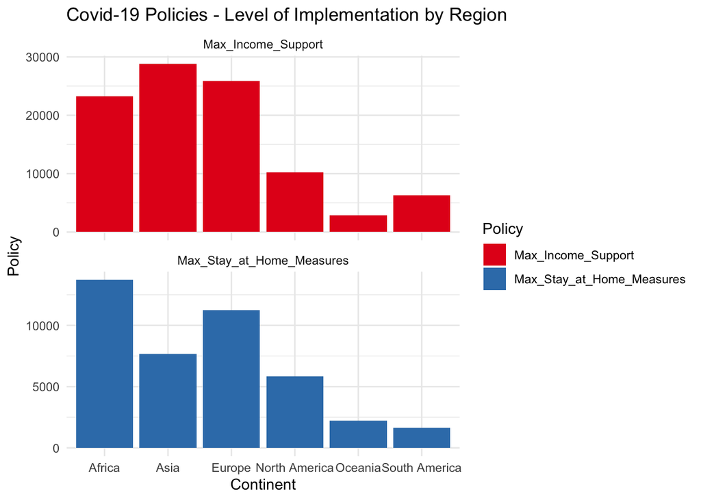

**Discussion**

- How was this graph made?

The above graph separates the world into the 6 regions of Africa, Asia, Europe, North America, South America and Oceania. It does so following the “Our World in Data” definition of the different world regions.

- What does this graph say?

This graph shows that, when it comes to income support, the region which provided the least was Oceania and the region which gave the most support was Asia where support is considered to be low when there is none given and high where the government is replacing 50% or more of lost salary.

The graph also shows a large contrast between the highly supportive regions of Africa, Europe and Asia and the regions with appear to be less supportive of Oceania, North and South America.

When it comes to stay at home measures, the least stringent region is South America and the most stringent is Africa. Africa and Europe appear to be relatively stricter in their stay at home measures (that is laws and policy which limits extent and reasons for which people can leave the house).

The contrast within the same region in the implementation of stay at home policies and income support shows that regions such as Africa and Europe appear to have, in general, implemented the most policies and to the most stringent extent whereas regions such as Oceania and South America had a more general relaxed approach. Other regions such as Asia show a high level of income support relative to their implementation of stay at home measures, indicating they may have prioritized economic prosperity and stability over public health concerns.

# Exercise 3 - Part 1

**Regular expression a**

The string transformation that the below function executes is the removal of the first letter:

```r
remove_first_letter <- function(input_string) {
  # Transformation pattern 1: Remove the first character
  transformed_string <- gsub("^.", "", input_string)
      return(transformed_string)
}

# Examples:
word1 <- "apple"
word2 <- "abbacus"
word3 <- "Annapolis"
word4 <- "Alphabet"

result1 <- remove_first_letter(word1)
result2 <- remove_first_letter(word2)
result3 <- remove_first_letter(word3)
result4 <- remove_first_letter(word4)

cat("Original word 1: ", word1, "\n")
```

```
## Original word 1:  apple
```

```r
cat("Modified word 1: ", result1, "\n\n")
```

```
## Modified word 1:  pple
```

```r
cat("Original word 2: ", word2, "\n")
```

```
## Original word 2:  abbacus
```

```r
cat("Modified word 2: ", result2, "\n\n")
```

```
## Modified word 2:  bbacus
```

```r
cat("Original word 3:", word3, "\n")
```

```
## Original word 3: Annapolis
```

```r
cat("Modified word 3: ", result3, "\n\n")
```

```
## Modified word 3:  nnapolis
```

```r
cat("Original word 4: ", word4, "\n")
```

```
## Original word 4:  Alphabet
```

```r
cat("Modified word 4: ", result4, "\n")
```

```
## Modified word 4:  lphabet
```

**Regular expression b**

```r
remove_lowercase_a <- function(input_string) {
  return(gsub("a", "", input_string, ignore.case = FALSE))
}

# Examples:
word1 <- "apple"
word2 <- "abbacus"
word3 <- "Annapolis"
word4 <- "Alphabet"

result1 <- remove_first_letter(word1)
result2 <- remove_first_letter(word2)
result3 <- remove_first_letter(word3)
result4 <- remove_first_letter(word4)

cat("Original word 1: ", word1, "\n")
```

```
## Original word 1:  apple
```

```r
cat("Modified word 1: ", result1, "\n\n")
```

```
## Modified word 1:  pple
```

```r
cat("Original word 2: ", word2, "\n")
```

```
## Original word 2:  abbacus
```

```r
cat("Modified word 2: ", result2, "\n\n")
```

```
## Modified word 2:  bbacus
```

```r
cat("Original word 3:", word3, "\n")
```

```
## Original word 3: Annapolis
```

```r
cat("Modified word 3: ", result3, "\n\n")
```

```
## Modified word 3:  nnapolis
```

```r
cat("Original word 4: ", word4, "\n")
```

```
## Original word 4:  Alphabet
```

```r
cat("Modified word 4: ", result4, "\n")
```

```
## Modified word 4:  lphabet
```

**Regular expression c**

The string transformation that the below function executes is the removal of all letters but the first one and the last two:

```r
remove_components <- function(input_string) {
  if (nchar(input_string) >= 3) {
    first_letter <- substr(input_string, 1, 1)
    last_two_letters <- substr(input_string, nchar(input_string) - 1, nchar(input_string))
    modified_string <- paste0(first_letter, last_two_letters)
  } else {
    modified_string <- input_string
  }

  return(modified_string)
}

# Examples:
word1 <- "C1_nat_a"
word2 <- "D2_state_g"
word3 <- "E_Loc_5_i"
word4 <- "A_reg_4_l"

result1 <- remove_components(word1)
result2 <- remove_components(word2)
result3 <- remove_components(word3)
result4 <- remove_components(word4)

cat("Original word 1: ", word1, "\n")
```

```
## Original word 1:  C1_nat_a
```

```r
cat("Modified word 1: ", result1, "\n\n")
```

```
## Modified word 1:  C_a
```

```r
cat("Original word 2: ", word2, "\n")
```

```
## Original word 2:  D2_state_g
```

```r
cat("Modified word 2: ", result2, "\n\n")
```

```
## Modified word 2:  D_g
```

```r
cat("Original word 3:", word3, "\n")
```

```
## Original word 3: E_Loc_5_i
```

```r
cat("Modified word 3: ", result3, "\n\n")
```

```
## Modified word 3:  E_i
```

```r
cat("Original word 4: ", word4, "\n")
```

```
## Original word 4:  A_reg_4_l
```

```r
cat("Modified word 4: ", result4, "\n")
```

```
## Modified word 4:  A_l
```

# Exercise 3 - Part 2

**Research question**

How often is the weather referenced in the english literary canon?

**Concept**

In this exercise we use two books - Moby Dick and Wuthering Heights - as proxies for the english literary cano and thus use them to examine how often is weather referenced in the western canon books. To measure the concept of weather, mentions of weather through words such as “rain”, “wind” and “sunny” are accounted for.

**Findings**

The findings show that: Total weather-related terms found in Moby Dick: 590 Total weather-related terms found in Wuthering heights: 277

This shows that in Mody Dick there a lot of references to the weather since approximately 0.28% of the words (590 of 209117) are references to the weather.

It also shows that in Wuthering heights also has a lot of references to the weather since approximately 0.23% of the words (277 of 119572 words) are references to the weather.

This indicates that weather is oftentimes referenced in these books and, with further analysis, we could see if this is the case solely in the western canon or in literature in general.

**Code**

[output not shown]

[output not shown]

[output not shown]

```
##            Document Weather_Count
## 1         Moby Dick             0
## 2 Wuthering Heights             0
```

```
## Total weather-related terms found in Moby Dick: 590
```

```
## Total weather-related terms found in Wuthering heights: 277
```

## Appendix: All code in this assignment

```r
knitr::opts_chunk$set(echo = FALSE) # Code set out in appendix

# EXERCISE 2 CODE

library(ggplot2)
library(dplyr)
library("RColorBrewer")

                                            # Step 1: Get Data and clean it

# Load the data from OxCGRT
covid_data <- read.csv("OxCGRT_compact_national_v1.csv")

# Load the data from "Our World in Data" to get regions of the world
region_data <-read.csv("continents-according-to-our-world-in-data.csv")

# Join data based on the 'CountryName' column in covid_data and 'Entity' column in region_data
merged_data <- covid_data %>%
  left_join(region_data, by = c("CountryName" = "Entity"))

# Save the merged data to a new CSV file if needed
write.csv(merged_data, "merged_data.csv", row.names = FALSE)

#Remove countries where no Continent is assigned
merged_data <- subset(merged_data, !is.na(Continent) & Continent != "")

                                            # Step 2: Find the maximum values

# Use the maximum level (eg.3 for C6 by Australia) to determine the extent of stay at home measures in this country

merged_data <- merged_data %>%
  group_by(CountryName) %>%
  mutate(Max_Stay_at_Home_Measures = ifelse(C6M_Stay.at.home.requirements == max(C6M_Stay.at.home.requirements), 1, 0)) %>%
  ungroup()


merged_data <- merged_data %>%
  group_by(CountryName) %>%
  mutate(Max_Income_Support = ifelse(E1_Income.support == max(E1_Income.support), 1, 0)) %>%
  ungroup()

                                              # Step 3: graph
#graph

merged_data_long <- tidyr::gather(merged_data, key = "Policy", value = "value", Max_Stay_at_Home_Measures, Max_Income_Support)

# Get color palettes from RColorBrewer
colors <- brewer.pal(8, "Set1")

# Create a bar plot with subplots for each policy
ggplot(merged_data_long, aes(x = Continent, y = value, fill = Policy)) +
  geom_bar(stat = "identity") +
  labs(y = "Policy") +
  facet_wrap(~ Policy, scales = "free_y", ncol = 1) +
  scale_fill_manual(values = colors[1:2]) +
  theme_minimal() +
  ggtitle("Covid-19 Policies - Level of Implementation by Region")


remove_first_letter <- function(input_string) {
  # Transformation pattern 1: Remove the first character
  transformed_string <- gsub("^.", "", input_string)
      return(transformed_string)
}

# Examples:
word1 <- "apple"
word2 <- "abbacus"
word3 <- "Annapolis"
word4 <- "Alphabet"

result1 <- remove_first_letter(word1)
result2 <- remove_first_letter(word2)
result3 <- remove_first_letter(word3)
result4 <- remove_first_letter(word4)

cat("Original word 1: ", word1, "\n")
cat("Modified word 1: ", result1, "\n\n")

cat("Original word 2: ", word2, "\n")
cat("Modified word 2: ", result2, "\n\n")

cat("Original word 3:", word3, "\n")
cat("Modified word 3: ", result3, "\n\n")

cat("Original word 4: ", word4, "\n")
cat("Modified word 4: ", result4, "\n")

remove_lowercase_a <- function(input_string) {
  return(gsub("a", "", input_string, ignore.case = FALSE))
}

# Examples:
word1 <- "apple"
word2 <- "abbacus"
word3 <- "Annapolis"
word4 <- "Alphabet"

result1 <- remove_first_letter(word1)
result2 <- remove_first_letter(word2)
result3 <- remove_first_letter(word3)
result4 <- remove_first_letter(word4)

cat("Original word 1: ", word1, "\n")
cat("Modified word 1: ", result1, "\n\n")

cat("Original word 2: ", word2, "\n")
cat("Modified word 2: ", result2, "\n\n")

cat("Original word 3:", word3, "\n")
cat("Modified word 3: ", result3, "\n\n")

cat("Original word 4: ", word4, "\n")
cat("Modified word 4: ", result4, "\n")


remove_components <- function(input_string) {
  if (nchar(input_string) >= 3) {
    first_letter <- substr(input_string, 1, 1)
    last_two_letters <- substr(input_string, nchar(input_string) - 1, nchar(input_string))
    modified_string <- paste0(first_letter, last_two_letters)
  } else {
    modified_string <- input_string
  }

  return(modified_string)
}

# Examples:
word1 <- "C1_nat_a"
word2 <- "D2_state_g"
word3 <- "E_Loc_5_i"
word4 <- "A_reg_4_l"

result1 <- remove_components(word1)
result2 <- remove_components(word2)
result3 <- remove_components(word3)
result4 <- remove_components(word4)

cat("Original word 1: ", word1, "\n")
cat("Modified word 1: ", result1, "\n\n")

cat("Original word 2: ", word2, "\n")
cat("Modified word 2: ", result2, "\n\n")

cat("Original word 3:", word3, "\n")
cat("Modified word 3: ", result3, "\n\n")

cat("Original word 4: ", word4, "\n")
cat("Modified word 4: ", result4, "\n")

# Load quanteda package
library("quanteda")
library("quanteda.textstats")

# Load the texts
moby_dick <- readLines("https://www.gutenberg.org/files/2701/2701-0.txt")
wuthering_heights <- readLines("https://www.gutenberg.org/files/768/768-0.txt")
combined_texts <- c(moby_dick, wuthering_heights)

# Create a corpus
corpus <- corpus(combined_texts)

# Create a character vector
text_vector <- c("Moby Dick" = paste(moby_dick, collapse = "\n"), "Wuthering Heights" = paste(wuthering_heights, collapse = "\n"))

# Tokenize the text
tokens_text <- tokens(text_vector)

# Define a dictionary of weather-related terms
weather_dictionary <- dictionary(list(
  rain = c("rain", "rainy", "raining"),
  snow = c("snow", "snowy", "snowing"),
  storm = c("storm", "stormy", "storming"),
  sun = c("sun", "sunny"),
  cloud = c("cloud", "cloudy"),
  wind = c("wind", "windy")
))

# Initialize an empty vector to store the counts
weather_counts <- c()

# Loop through each document in the tokens and count the occurrences
for (doc in seq_along(tokens_text)) {
  counts <- table(tokens_text[[doc]])  # Count the terms in the document
  weather_counts[doc] <- sum(counts[rownames(weather_dictionary)])  # Sum counts of weather terms
}

# Create a data frame with document names and weather-related term counts
weather_counts_df <- data.frame(Document = docnames(tokens_text), Weather_Count = weather_counts)

# Display the counts
print(weather_counts_df)
# Load the texts
moby_dick <- readLines("https://www.gutenberg.org/files/2701/2701-0.txt")

# Define a dictionary of weather-related terms
weather_dictionary <- list(
  rain = c("rain", "rainy", "raining"),
  snow = c("snow", "snowy", "snowing"),
  storm = c("storm", "stormy", "storming"),
  sun = c("sun", "sunny"),
  cloud = c("cloud", "cloudy"),
  wind = c("wind", "windy")
)

# Tokenize the text and count weather-related terms
library(stringr)

# Combine all the weather-related terms into a single vector
weather_terms <- unlist(weather_dictionary)

# Tokenize the text and count matches
term_counts <- str_count(tolower(moby_dick), paste(weather_terms, collapse = "|"))

# Calculate the total count
total_count <- sum(term_counts)

# Print the results
cat("Total weather-related terms found in Moby Dick:", total_count)
# Load the texts
wuthering_heights <- readLines("https://www.gutenberg.org/files/768/768-0.txt")

# Define a dictionary of weather-related terms
weather_dictionary <- list(
  rain = c("rain", "rainy", "raining"),
  snow = c("snow", "snowy", "snowing"),
  storm = c("storm", "stormy", "storming"),
  sun = c("sun", "sunny"),
  cloud = c("cloud", "cloudy"),
  wind = c("wind", "windy")
)

# Tokenize the text and count weather-related terms
library(stringr)

# Combine all the weather-related terms into a single vector
weather_terms <- unlist(weather_dictionary)

# Tokenize the text and count matches
term_counts <- str_count(tolower(wuthering_heights), paste(weather_terms, collapse = "|"))

# Calculate the total count
total_count <- sum(term_counts)

# Print the results
cat("Total weather-related terms found in Wuthering heights:", total_count)
# this chunk generates the complete code appendix.
# eval=FALSE tells R not to run (``evaluate'') the code here (it was already run before).
```